# Car Prices

## Background

Previous work has been done on the effect of mileage on the prices of Cadillacs. That work can be viewed here. Analysis of Cadillacs The linear regression was effective in many ways but was unable to effectively predict the price of a Cadillac Deville.

The purpose of this analysis is to focus on only the Cadillac Devilles and to provide a more in-depth interpretation.

Below is the subsetted data set.

```r
datatable(CarPrices1, options=list(lengthMenu = c(3,10,30)))
```

|  | Price | Mileage | Make | Model | Trim | Type | Cylinder | Liter | Doors | Cruise | Sound | Leather |
| --- | --- | --- | --- | --- | --- | --- | --- | --- | --- | --- | --- | --- |
| 101 | 39801.55135 | 14095 | Cadillac | Deville | DHS Sedan 4D | Sedan | 8 | 4.6 | 4 | 1 | 0 | 1 |
| 102 | 40335.73731 | 14743 | Cadillac | Deville | DHS Sedan 4D | Sedan | 8 | 4.6 | 4 | 1 | 0 | 1 |
| 103 | 39307.00916 | 16041 | Cadillac | Deville | DHS Sedan 4D | Sedan | 8 | 4.6 | 4 | 1 | 0 | 1 |
| 104 | 38600.23956 | 17138 | Cadillac | Deville | DHS Sedan 4D | Sedan | 8 | 4.6 | 4 | 1 | 0 | 1 |
| 105 | 38445.89717 | 18661 | Cadillac | Deville | DHS Sedan 4D | Sedan | 8 | 4.6 | 4 | 1 | 0 | 1 |
| 106 | 36077.79612 | 21966 | Cadillac | Deville | DHS Sedan 4D | Sedan | 8 | 4.6 | 4 | 1 | 0 | 1 |
| 107 | 35866.58271 | 24415 | Cadillac | Deville | DHS Sedan 4D | Sedan | 8 | 4.6 | 4 | 1 | 1 | 1 |
| 108 | 35338.65369 | 25163 | Cadillac | Deville | DHS Sedan 4D | Sedan | 8 | 4.6 | 4 | 1 | 0 | 1 |
| 109 | 36154.30355 | 25339 | Cadillac | Deville | DHS Sedan 4D | Sedan | 8 | 4.6 | 4 | 1 | 1 | 1 |
| 110 | 34685.66298 | 25421 | Cadillac | Deville | DHS Sedan 4D | Sedan | 8 | 4.6 | 4 | 1 | 0 | 1 |

[output cut: 20 more lines]

## Hypothesis

This analysis will specifically look at whether there is a difference in slopes between each type of Trim option of the Deville.

$$H_0: \beta_1 = \beta_2 = \beta_3 = 0$$
$$H_a: \text{At least one} \ \beta_i \neq 0$$
$$\alpha = 0.05$$
Where, $\beta_1$ is the slope of the DHS Sedan 4D, $\beta_2$ is the slope of DTS Sedan 4D, and $\beta_3$ is the slope of Sedan 4D.

## Analysis

To provide the best linear regression model for the price of Cadillic Devilles another factor would need to be added to provide additional detail to the model. The only known difference of Cadillacs available to us besides `Model` is `Sound` and `Trim`. The residuals of the linear regression of only mileage and price were plotted with Sound and then Trim. Sound made no apparent difference but Trim did make a noticeable change in residuals or in other words, trim was able to identify trends in the residuals. The plot is shown below.

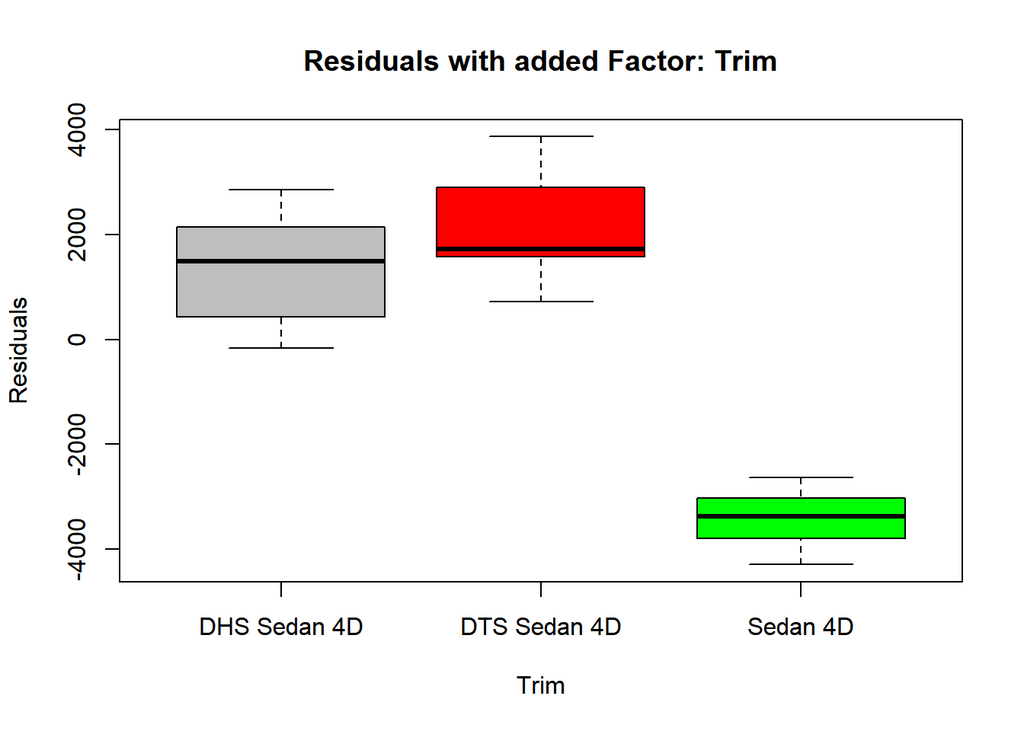

```r
Dv.lm <- lm(Price ~ Mileage, data=CarPrices1)
boxplot(Dv.lm$residuals ~ Trim, data=CarPrices1, col=c("grey", "red", "green"), main="Residuals with added Factor: Trim", ylab="Residuals", xlab="Trim")
```

Because Trim was to explain the trends of the residuals it was added to the linear regression model and interactions between the variables were allowed. The summary of the results as follows,

```r
Dv2.lm <- lm(Price ~ Mileage * Trim,data=CarPrices1)
b <- Dv2.lm$coefficients
pander(summary(Dv2.lm))
```

|  | Estimate | Std. Error | t value | Pr(>\|t\|) |
| --- | --- | --- | --- | --- |
| **(Intercept)** | 46151 | 885.2 | 52.13 | 3.272e-26 |
| **Mileage** | -0.4281 | 0.04261 | -10.05 | 4.49e-10 |
| **TrimDTS Sedan 4D** | -1731 | 975.6 | -1.774 | 0.08875 |
| **TrimSedan 4D** | -8132 | 1035 | -7.86 | 4.308e-08 |
| **Mileage:TrimDTS Sedan 4D** | 0.1246 | 0.04589 | 2.716 | 0.01205 |
| **Mileage:TrimSedan 4D** | 0.1621 | 0.05122 | 3.164 | 0.004185 |

Fitting linear model: Price ~ Mileage * Trim

| Observations | Residual Std. Error | $R^2$ | Adjusted $R^2$ |
| --- | --- | --- | --- |
| 30 | 595.3 | 0.9731 | 0.9675 |

The p-values 4.49e-10, 0.01205, .004185 are all lower than 0.05. These are significant values and leads us to reject the null hypothesis. At least one of the slopes of the true line is not equal to zero. From the graph below it appears that there are three distinct lines.

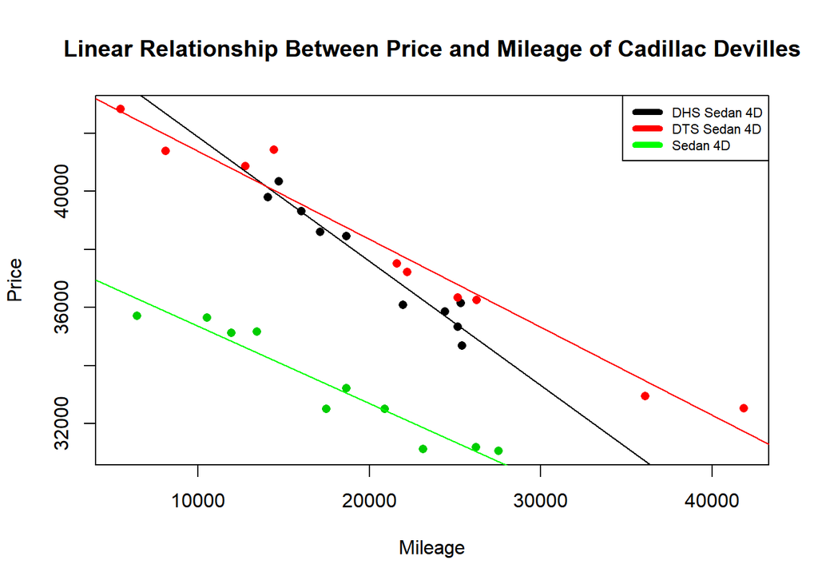

```r
plot(Price ~ Mileage, data=CarPrices1, pch = 16, col=CarPrices1$Trim, main="Linear Relationship Between Price and Mileage of Cadillac Devilles")
abline(b[1], b[2])
abline(b[1]+b[3], b[2]+b[5], col="red")
abline(b[1]+b[4], b[2]+b[6], col="green")
legend("topright",Dv2.lm$xlevels$Trim, lty=1, lwd=5, col=c("black", "red", "green"), cex=0.7)
```

It can be seen from the plot above that the model had captured three distinct linear lines.

#### Checking Assumptions

To insure the validity of the test here are two additional plots.

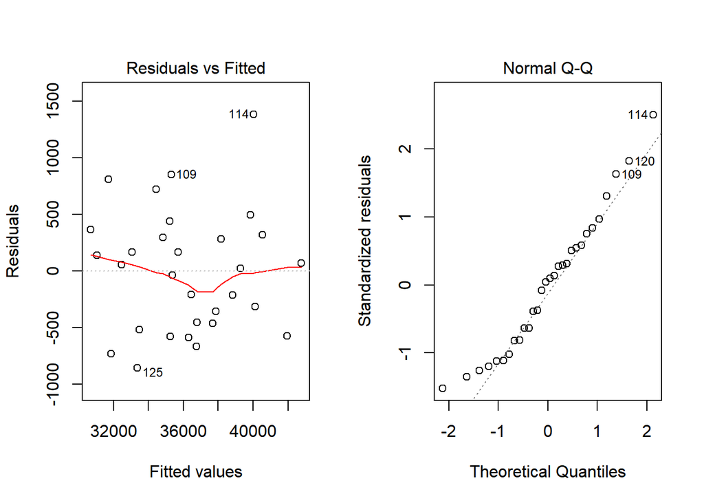

```r
par(mfrow=c(1,2))
plot(Dv2.lm, which=1:2)
```

The plots above demonstrate that the test was appropriate. The residuals vs fitted plot shows that a linear relationship exists. There is a slight trend showing, but this is not considered significant enough to discredit the test. The plot also shows that there is constant variance.

The Quantile plot also shows that the residuals are normally distributed, proving that the error terms also follow a normal distribution.

## Interpretation

The null hypothesis of this analysis is that all 3 slopes are equal to zero, or that there is no correlation. Because the p-values for slopes are below 0.05 the null is rejected in favor of the alternative, in that at least one of the slopes is not equal to zero. Meaning that there is a correlation between these variables.

After proving the validity of the multiple linear regression confidence can be placed in the results of the test. For anyone who wants to know the estimated value or rate a depreciation of a Cadillac Deville will need to know the exact trim option, DHS, DTS, or regular Sedan 4D, because each are expected to follow a unique linear line.

This will likely be true for all other types of cars, but further studies should be done to prove that.